# 6_capitulo

2023-02-13

```r
vic_elec_filtro <-vic_elec %>%
  dplyr::filter(as.Date(Time) >= as.Date("2012-01-01"), as.Date(Time) <= as.Date("2012-01-15"))%>%
  index_by(Date = as.Date(Date))%>%
  summarise(
    demanda = sum(Demand),
    temperatura_maxima = max(Temperature)
  )
```

##a)Plote os dados e encontre o modelo de regressão para Demanda com temperatura como variável preditora. Por que existe uma relação positiva?

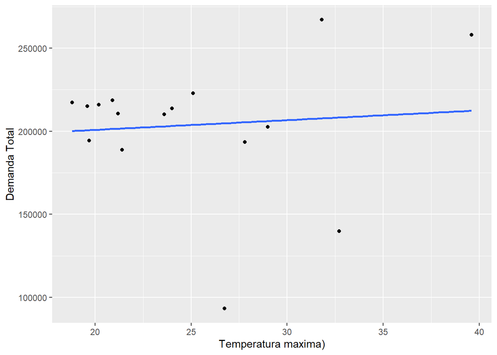

```r
vic_elec_filtro%>%
            ggplot(aes(temperatura_maxima,demanda))+
           labs(y = "Demanda Total",
            x = "Temperatura maxima)") +
            geom_point(color='black')+
            geom_smooth(method = "lm", se = FALSE)
```

```r
modelo_regressao <- vic_elec_filtro %>%model(TSLM(demanda ~ temperatura_maxima))
```

```r
modelo_regressao%>%
  report()
```

```
## Series: demanda
## Model: TSLM
##
## Residuals:
##     Min      1Q  Median      3Q     Max
## -111583   -7756    9830   17234   59352
##
## Coefficients:
##                    Estimate Std. Error t value Pr(>|t|)
## (Intercept)          189143      47890   3.950  0.00145 **
## temperatura_maxima      585       1859   0.315  0.75763
## ---
## Signif. codes:  0 '***' 0.001 '**' 0.01 '*' 0.05 '.' 0.1 ' ' 1
##
## Residual standard error: 42030 on 14 degrees of freedom
## Multiple R-squared: 0.007024,    Adjusted R-squared: -0.0639
## F-statistic: 0.09903 on 1 and 14 DF, p-value: 0.75763
```

## b)Produzir uma parcela residual. O modelo é adequado? Existem outliers ou observações influentes?

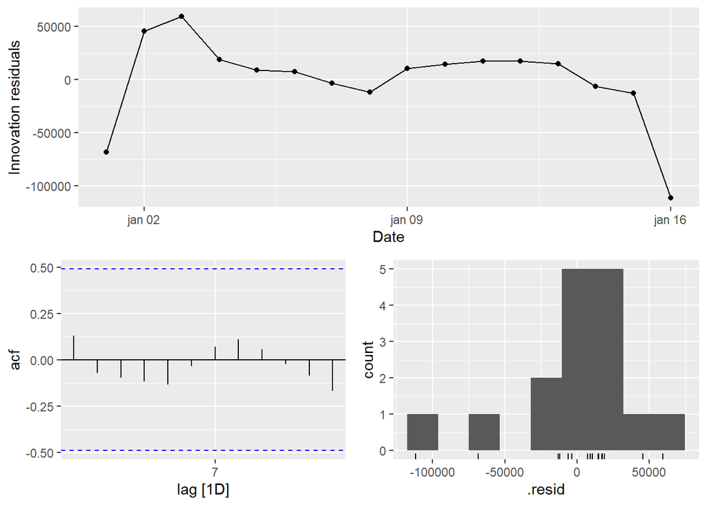

```r
modelo_regressao%>%gg_tsresiduals()
```

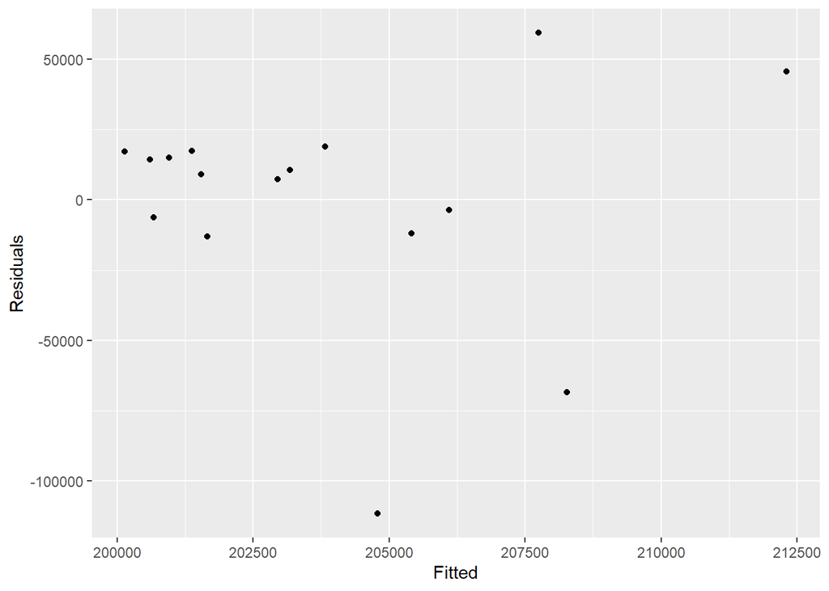

```r
#Gráficos residuais em relação aos valores ajustados
#Um gráfico dos resíduos em relação aos valores ajustados também não deve mostrar nenhum padrão. Se for observado um padrão, pode haver “heteroscedasticidade” nos erros, o que significa que a variância dos #resíduos pode não ser constante. Se esse problema ocorrer, pode ser necessária uma transformação da variável de previsão, como logaritmo ou raiz quadrada (consulte a Seção 3.1 ).
augment(modelo_regressao)%>%ggplot(aes(x = .fitted, y = .resid)) +
   geom_point() + labs(x = "Fitted", y = "Residuals")
```

##c)Use o modelo para prever a demanda de eletricidade que você esperaria para o dia seguinte se a temperatura máxima fosse 15∘C e compare com a previsão se a temperatura máxima foi 35∘C. Você acredita nessas previsões? O seguinte código R irá ajudá-lo a começar:

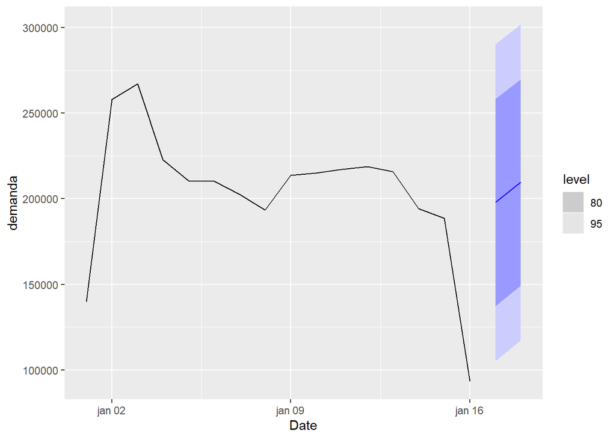

```r
nova_data <- c(15)

vic_elec_filtro %>%
  model(TSLM(demanda ~ temperatura_maxima))%>%
  forecast(
    new_data(vic_elec_filtro, 2) %>%
      mutate(temperatura_maxima = c(15,35))
  ) %>%
  autoplot(vic_elec_filtro)
```

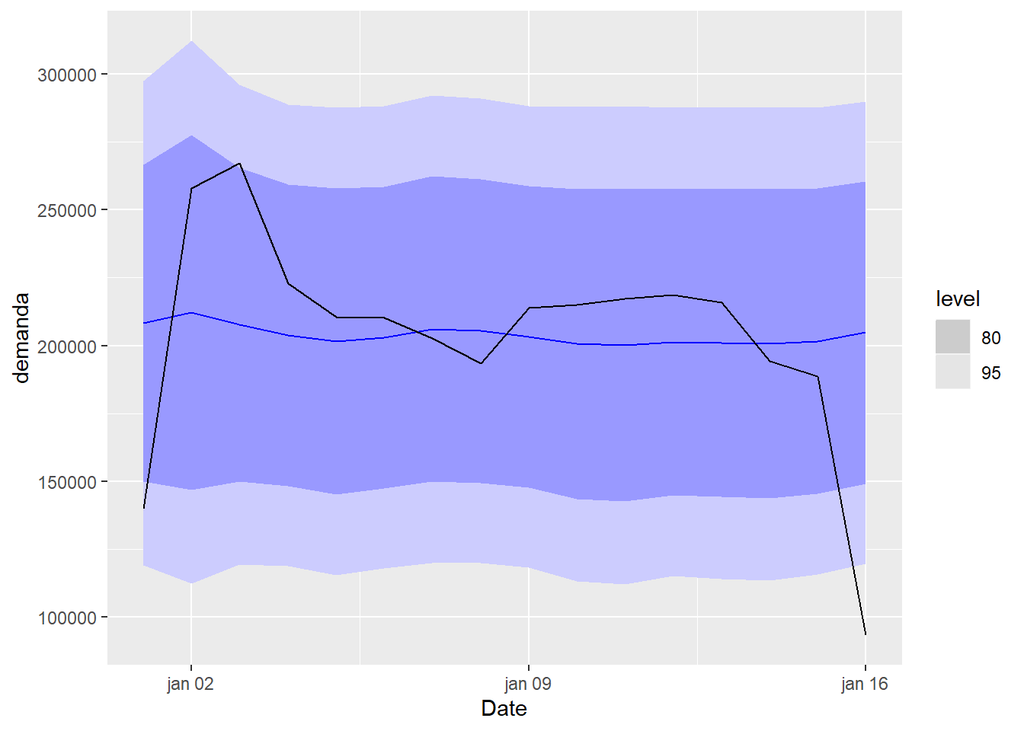

```r
#Traçar Demanda vs Temperatura para todos os dados disponíveis vic_elecagregados à demanda total diária e temperatura máxima. O que isso diz sobre o seu modelo?

vic_elec_filtro %>%
  model(TSLM(demanda ~ temperatura_maxima))%>%
  forecast(new_data=vic_elec_filtro) %>%
  autoplot(vic_elec_filtro)
```

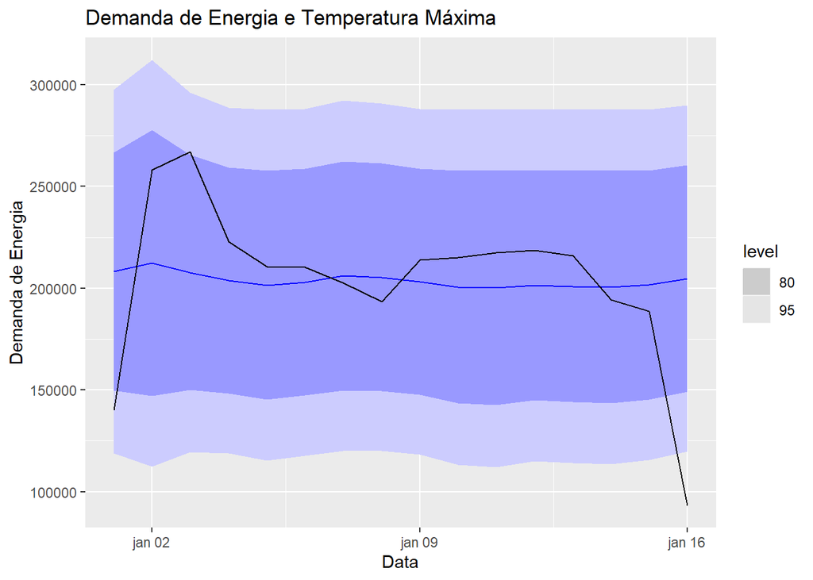

```r
vic_elec_filtro %>%
  model(TSLM(demanda ~ temperatura_maxima)) %>%
  forecast(new_data = vic_elec_filtro) %>%
  autoplot(vic_elec_filtro) +
  labs(x = "Data", y = "Demanda de Energia", title = "Demanda de Energia e Temperatura Máxima") +
  scale_color_manual(values = c("blue", "red"),
                     labels = c("Demanda de Energia", "Temperatura Máxima"))
```

##2)O conjunto de dados olympic_runningcontém os tempos de vitória (em segundos) em cada sprint dos Jogos Olímpicos, eventos de pista de meia distância e longa distância de 1896 a 2016.

```r
#a)Traçar o tempo de vitória contra o ano para cada evento. Descreva as principais características do enredo.

unique(olympic_running$Length)
```

```
## [1]   100   200   400   800  1500  5000 10000
```

```
## Plot variable not specified, automatically selected `.vars = Time`
```

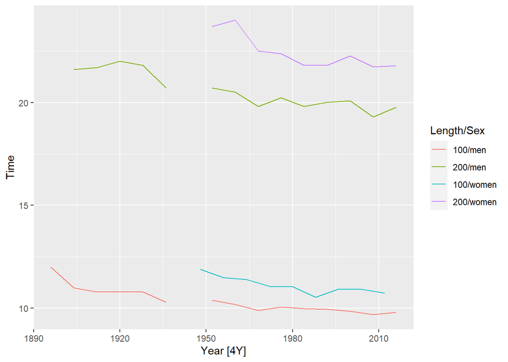

```r
olympic_running%>%
  filter(Length == c(100,200))%>%
  autoplot()
```

```
## Plot variable not specified, automatically selected `.vars = Time`
```

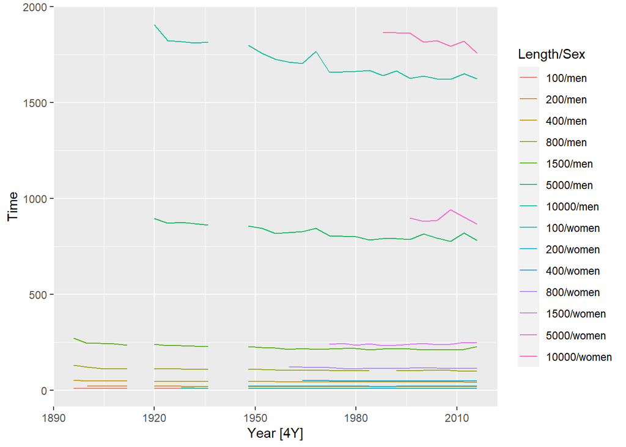

```r
olympic_running%>%
  autoplot()
```

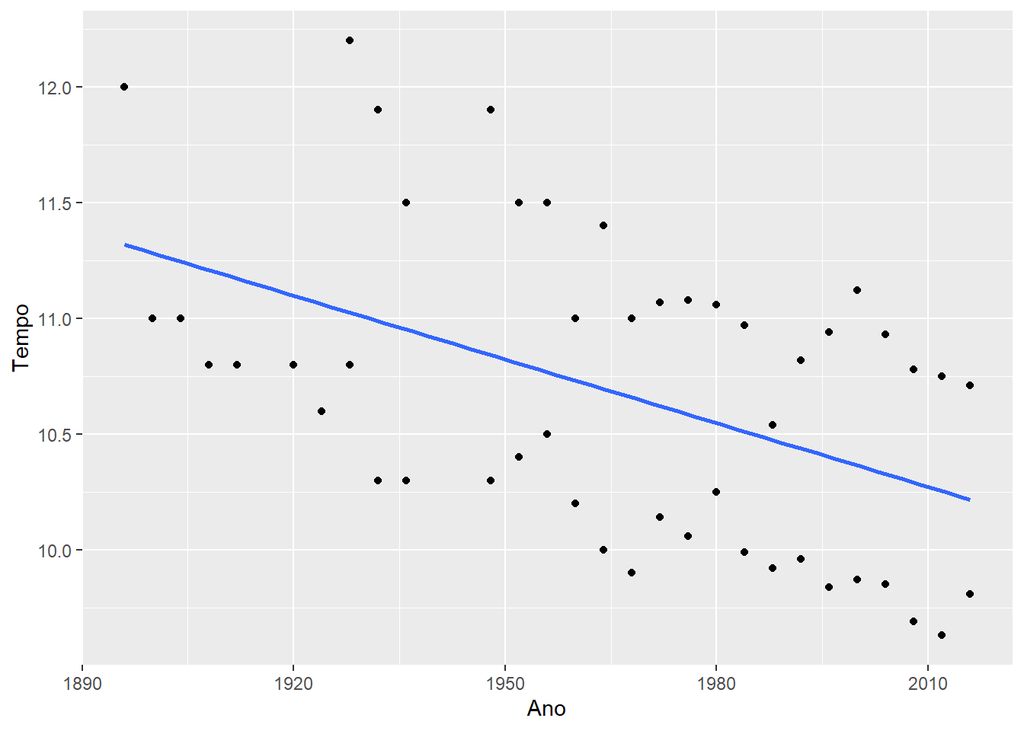

```r
##Ajuste uma linha de regressão aos dados de cada evento. Obviamente, os tempos de vitória têm diminuído, mas a que taxa média por ano?

olympic_running%>%
  filter(Length == 100)%>%
  ggplot(aes(Year,Time))+
           labs(y = "Tempo",
            x = "Ano") +
            geom_point(color='black')+
            geom_smooth(method = "lm", se = FALSE)
```

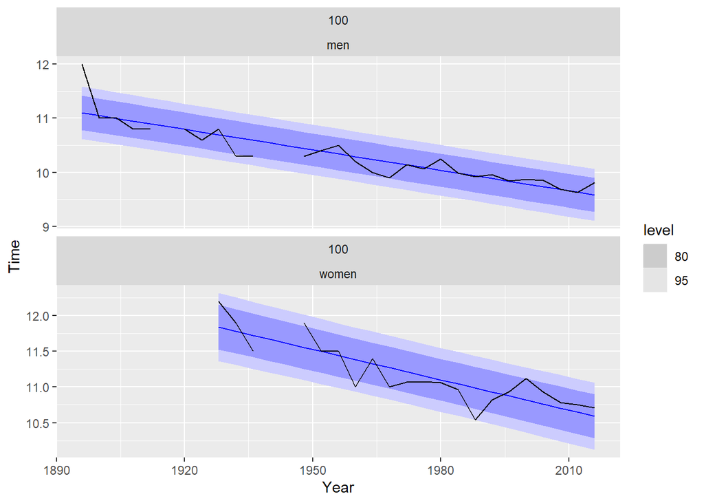

```r
modelo_100 <-olympic_running%>%
  filter(Length == 100)%>%
  model(TSLM(Time ~ Year))

modelo_100%>%
  forecast(new_data = olympic_running) %>%
  autoplot(olympic_running)
```

```r
modelo_100%>%
  filter(Sex == 'men')%>%
  report()
```

```
## Series: Time
## Model: TSLM
##
## Residuals:
##        Min         1Q     Median         3Q        Max
## -0.3443995 -0.1081360  0.0007715  0.0750701  0.9015537
##
## Coefficients:
##              Estimate Std. Error t value           Pr(>|t|)
## (Intercept) 35.011581   2.347437   14.91 0.0000000000000294 ***
## Year        -0.012612   0.001198  -10.52 0.0000000000724032 ***
## ---
## Signif. codes:  0 '***' 0.001 '**' 0.01 '*' 0.05 '.' 0.1 ' ' 1
##
## Residual standard error: 0.2321 on 26 degrees of freedom
## Multiple R-squared: 0.8099,  Adjusted R-squared: 0.8026
## F-statistic: 110.8 on 1 and 26 DF, p-value: 0.000000000072403
```

```r
modelo_100%>%
  filter(Sex == 'women')%>%
  report()
```

```
## Series: Time
## Model: TSLM
##
## Residuals:
##      Min       1Q   Median       3Q      Max
## -0.44833 -0.11159  0.05775  0.11731  0.36057
##
## Coefficients:
##              Estimate Std. Error t value      Pr(>|t|)
## (Intercept) 39.188164   3.697686  10.598 0.00000000205 ***
## Year        -0.014185   0.001872  -7.577 0.00000037226 ***
## ---
## Signif. codes:  0 '***' 0.001 '**' 0.01 '*' 0.05 '.' 0.1 ' ' 1
##
## Residual standard error: 0.2232 on 19 degrees of freedom
## Multiple R-squared: 0.7513,  Adjusted R-squared: 0.7382
## F-statistic:  57.4 on 1 and 19 DF, p-value: 0.00000037226
```

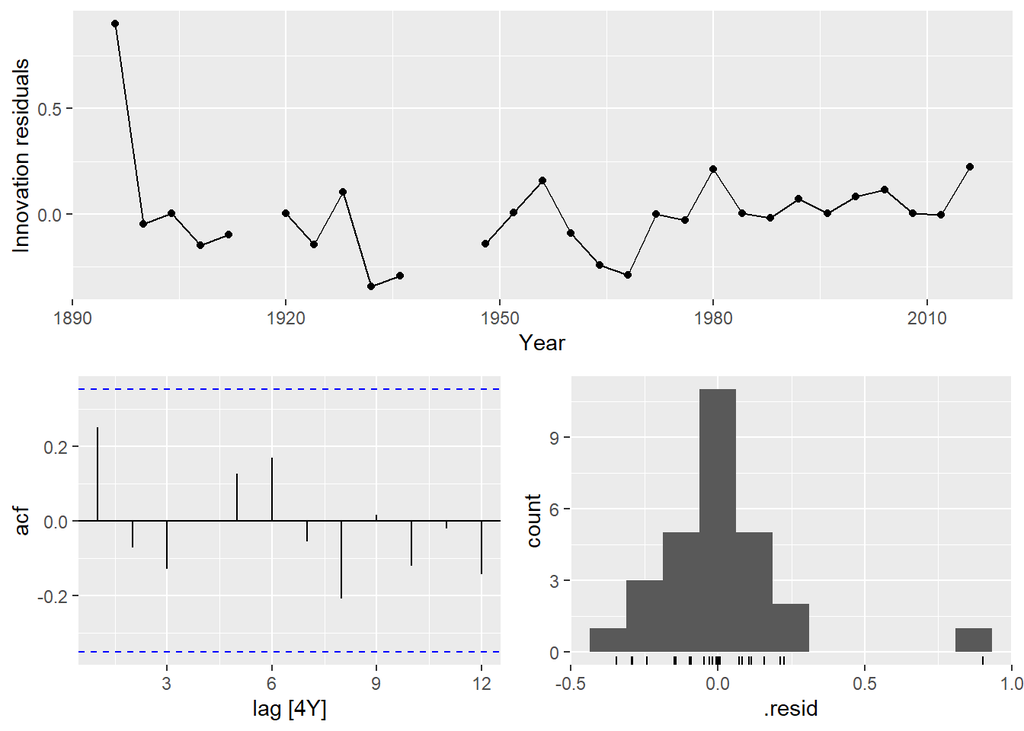

```r
#Plote os resíduos em relação ao ano. O que isso indica sobre a adequação das linhas ajustadas?
modelo_100 %>%
    filter(Sex == 'men')%>%
    gg_tsresiduals()
```

[figure not shown]

[output not shown]

```r
modelo_100 %>%
    filter(Sex == 'women')%>%
    gg_tsresiduals()
```

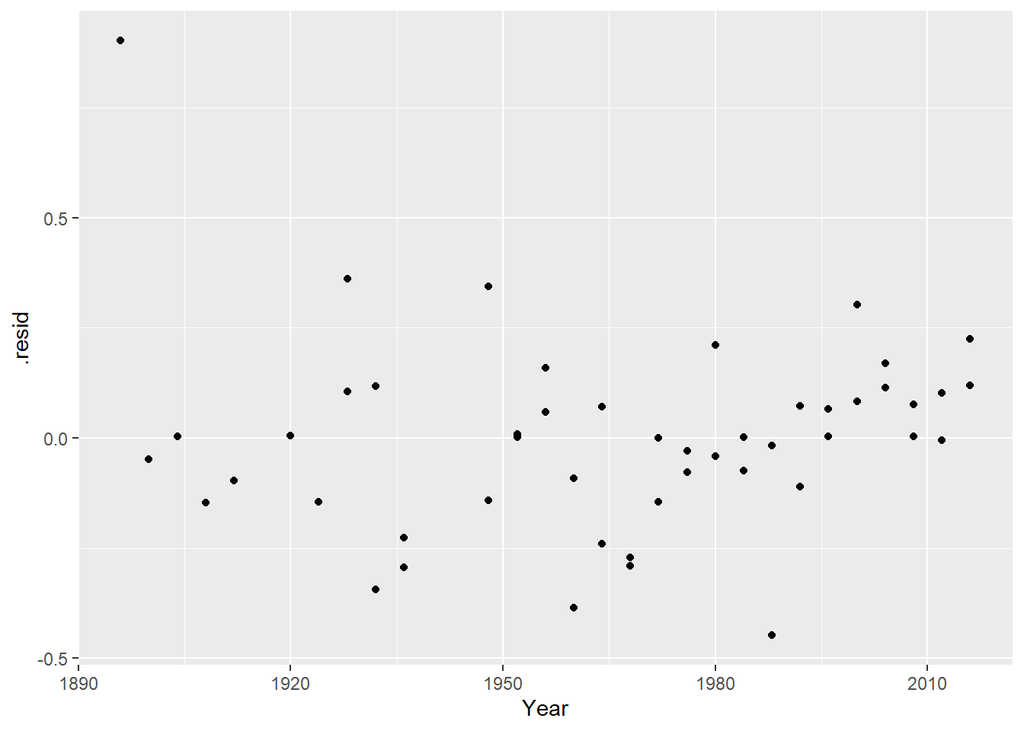

```r
merged_ts%>%
  tidyr::drop_na()%>%
  ggplot(aes(x = Year, y = .resid)) +
  geom_point()
```

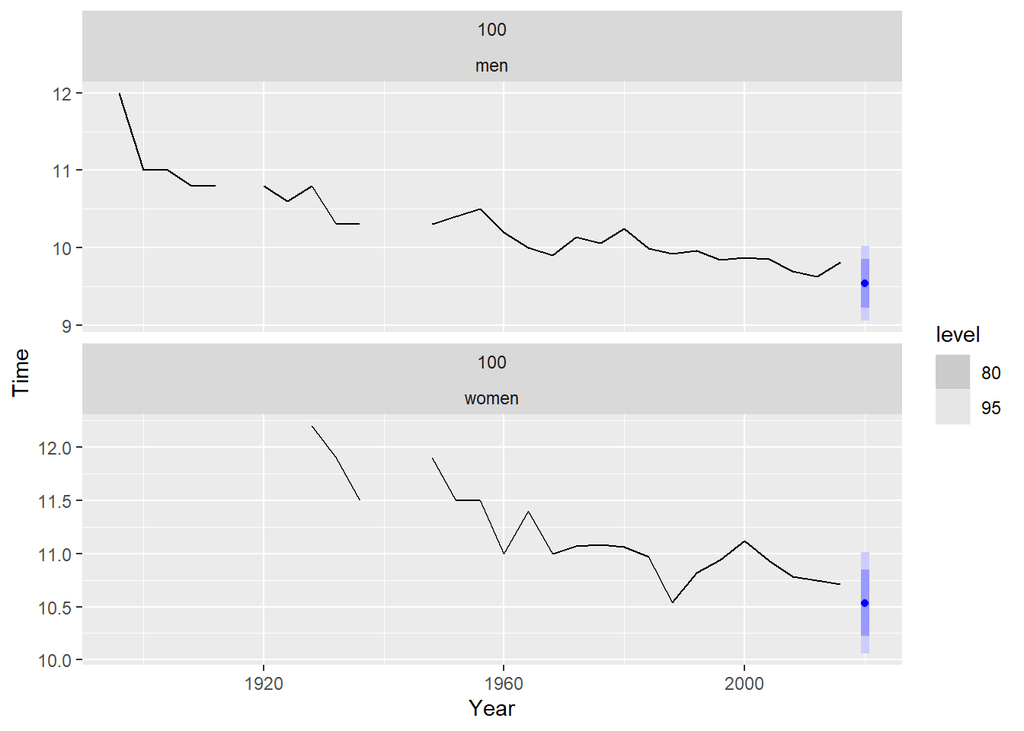

```r
###d)Preveja o tempo de vitória para cada corrida nas Olimpíadas de 2020. Dê um intervalo de previsão para suas previsões. Que suposições você fez nesses cálculos?



olympic_running%>%
  filter(Length==100)%>%
  model(TSLM(Time ~ Year))%>%
  forecast(
    new_data(olympic_running, 1) %>%
      mutate(Year= 2020)
  ) %>%
  autoplot(olympic_running)
```

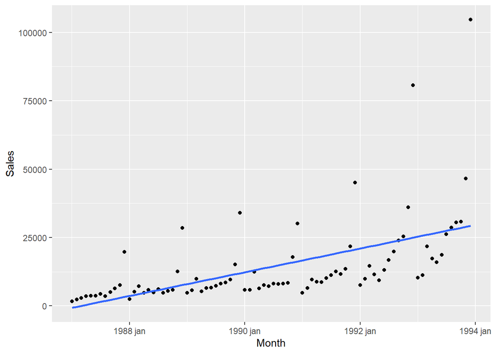

```r
###a)Produza um gráfico de tempo dos dados e descreva os padrões no gráfico. Identifique quaisquer flutuações incomuns ou inesperadas na série temporal.

souvenirs%>%
  ggplot(aes(x=Month,y=Sales))+
  geom_point()+
  geom_smooth(method = "lm", se = FALSE)
```

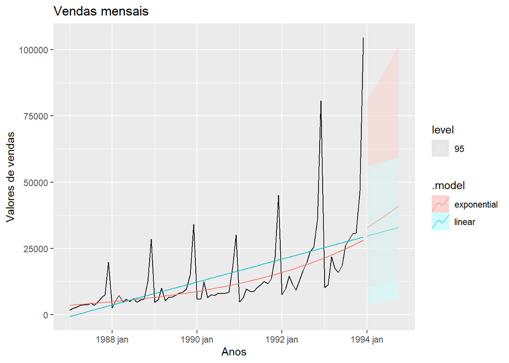

```r
#Explique por que é necessário obter logaritmos desses dados antes de ajustar um modelo.
fit_vendas <- souvenirs %>%
  model(
    linear = TSLM(Sales ~ Month),
    exponential = TSLM(log(Sales) ~ Month))
fc_vendas <- fit_vendas %>% forecast(h = 10)

souvenirs %>%
  autoplot(Sales) +
  geom_line(data = fitted(fit_vendas),
            aes(y = .fitted, colour = .model)) +
  autolayer(fc_vendas, alpha = 0.5, level = 95) +
  labs(y = "Valores de vendas",
      x="Anos",
       title = "Vendas mensais")
```

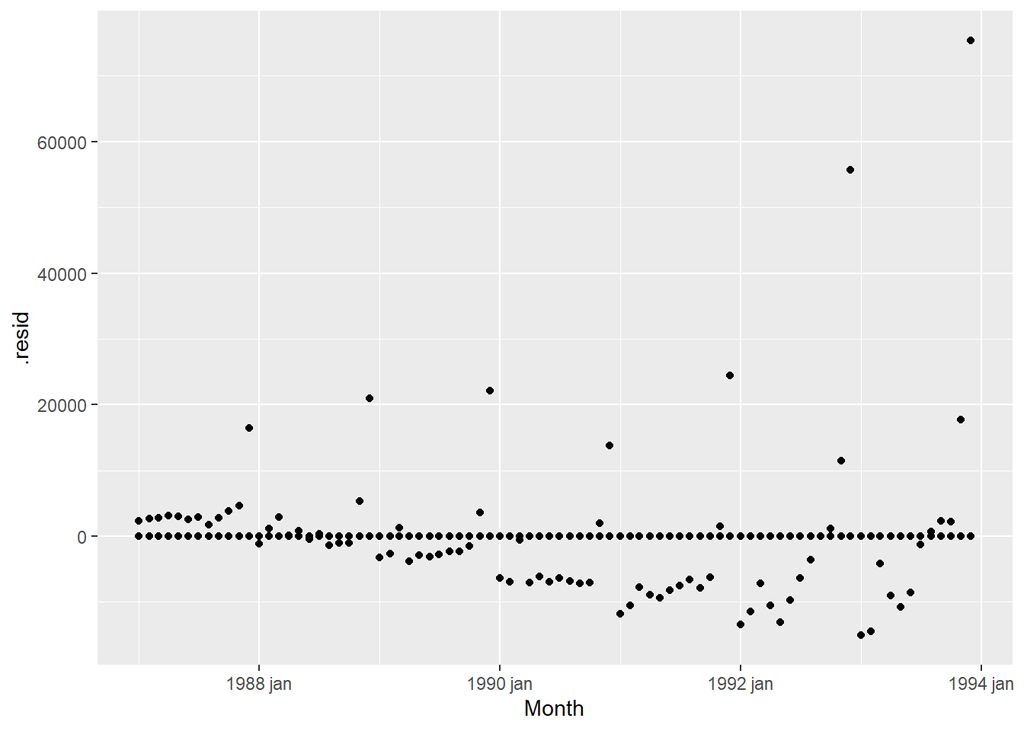

```r
#Plote os resíduos contra o tempo e contra os valores ajustados. Esses gráficos revelam algum problema com o modelo?

residuals_ts <- as_tsibble(residuals(fit_vendas), index = Month)

#residuos contra o tempo
residuals_ts%>%
  ggplot(aes(x = Month, y = .resid)) +
  geom_point()
```

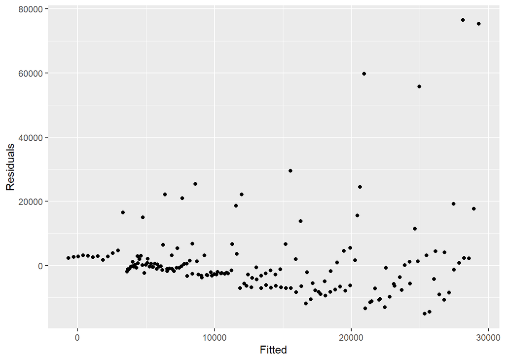

```r
#Residuos contra os valores ajustados
augment(fit_vendas) %>%
  ggplot(aes(x = .fitted, y = .resid)) +
  geom_point() + labs(x = "Fitted", y = "Residuals")
```

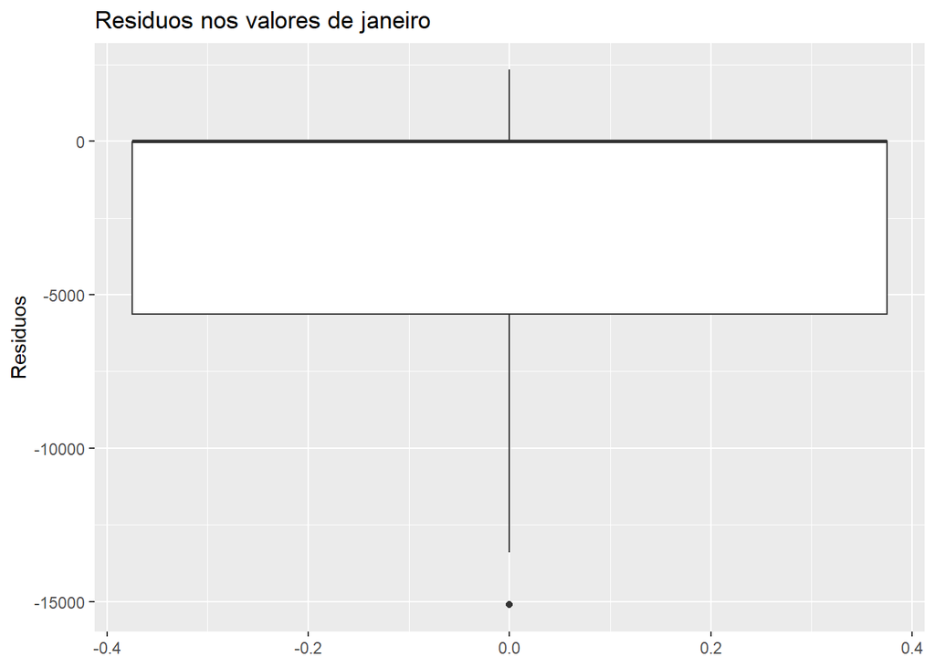

```r
#Faça boxplots dos resíduos para cada mês. Isso revela algum problema com o modelo?


residuals_ts %>%
  filter(grepl("jan", Month))%>%
  ggplot(aes(y=.resid))+
  geom_boxplot()+
  labs(y = "Residuos",
       title = "Residuos nos valores de janeiro")
```

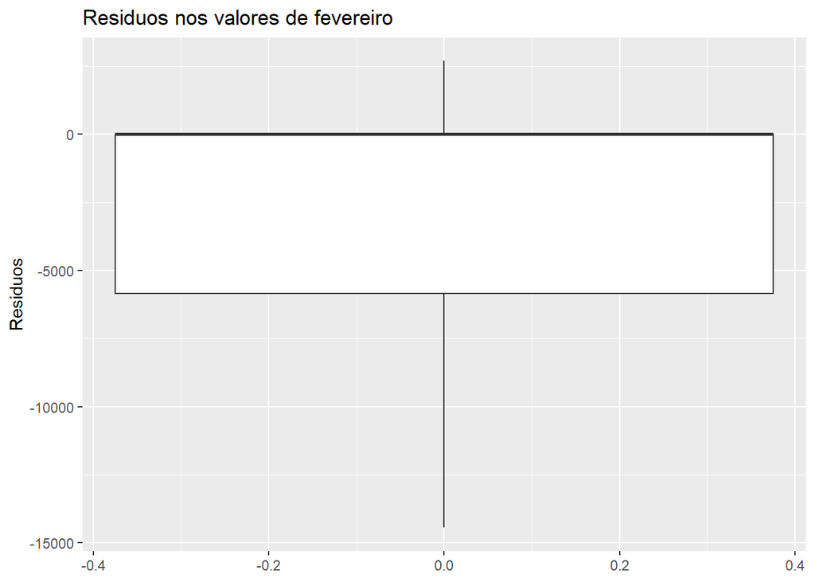

```r
residuals_ts %>%
  filter(grepl("fev", Month))%>%
  ggplot(aes(y=.resid))+
  geom_boxplot()+
  labs(y = "Residuos",
       title = "Residuos nos valores de fevereiro")
```

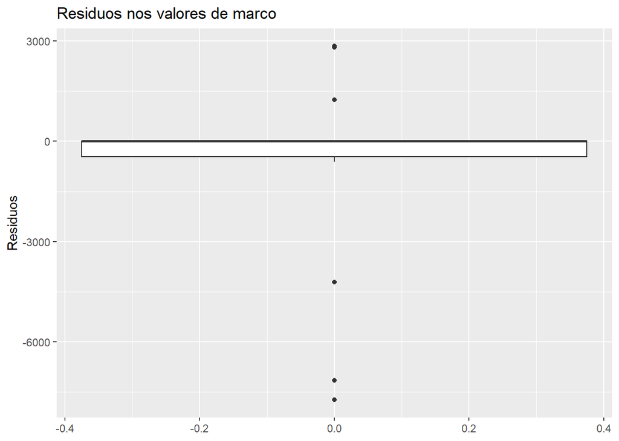

```r
residuals_ts %>%
  filter(grepl("mar", Month))%>%
  ggplot(aes(y=.resid))+
  geom_boxplot()+
  labs(y = "Residuos",
       title = "Residuos nos valores de marco")
```

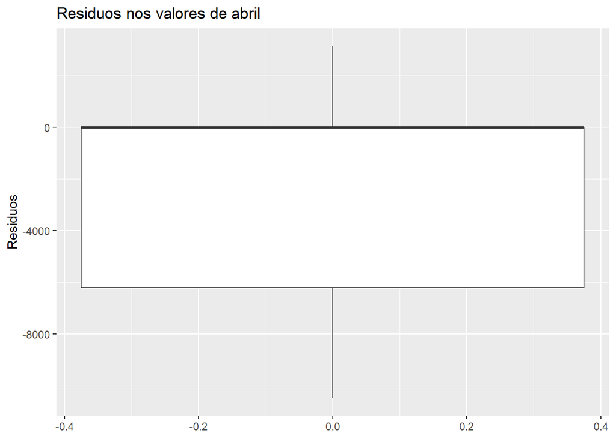

```r
residuals_ts %>%
  filter(grepl("abr", Month))%>%
  ggplot(aes(y=.resid))+
  geom_boxplot()+
  labs(y = "Residuos",
       title = "Residuos nos valores de abril")
```

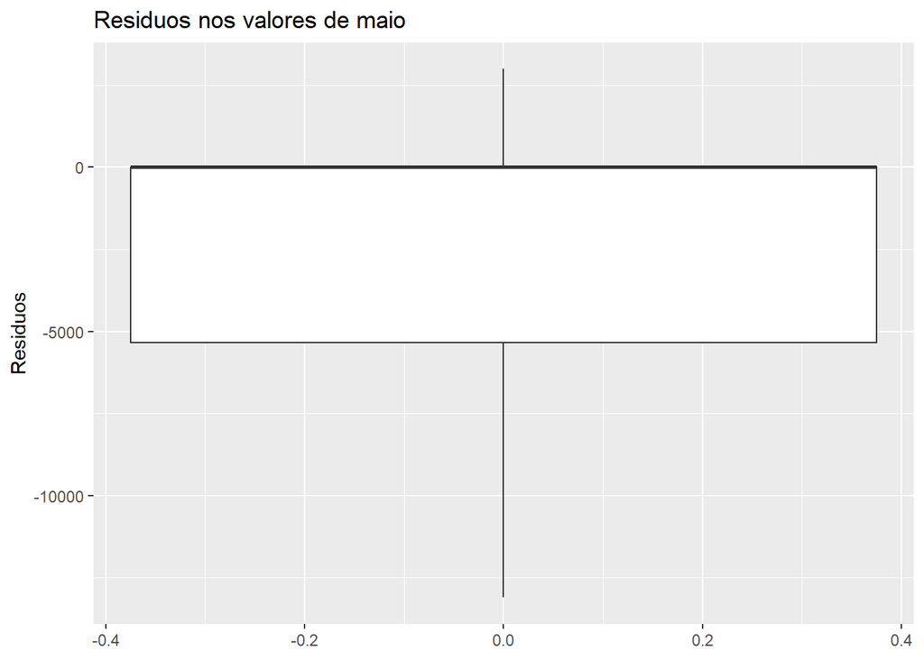

```r
residuals_ts %>%
  filter(grepl("mai", Month))%>%
  ggplot(aes(y=.resid))+
  geom_boxplot()+
  labs(y = "Residuos",
       title = "Residuos nos valores de maio")
```

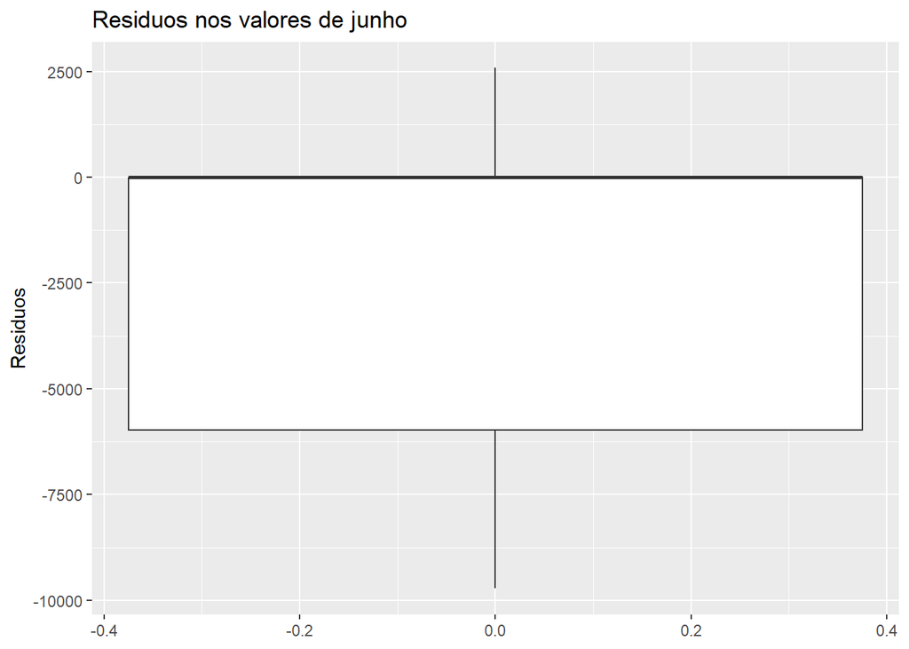

```r
residuals_ts %>%
  filter(grepl("jun", Month))%>%
  ggplot(aes(y=.resid))+
  geom_boxplot()+
  labs(y = "Residuos",
       title = "Residuos nos valores de junho")
```

```r
#f)O que os valores dos coeficientes dizem sobre cada variável?

report(fit_vendas%>%
        select(linear))
```

```
## Series: Sales
## Model: TSLM
##
## Residuals:
##    Min     1Q Median     3Q    Max
## -15097  -7053  -1500   2391  75358
##
## Coefficients:
##               Estimate Std. Error t value     Pr(>|t|)
## (Intercept) -74313.980  14578.023  -5.098 0.0000021689 ***
## Month           11.862      1.942   6.109 0.0000000321 ***
## ---
## Signif. codes:  0 '***' 0.001 '**' 0.01 '*' 0.05 '.' 0.1 ' ' 1
##
## Residual standard error: 13130 on 82 degrees of freedom
## Multiple R-squared: 0.3128,  Adjusted R-squared: 0.3044
## F-statistic: 37.32 on 1 and 82 DF, p-value: 0.000000032065
```

```r
report(fit_vendas%>%
        select(exponential))
```

```
## Series: Sales
## Model: TSLM
## Transformation: log(Sales)
##
## Residuals:
##      Min       1Q   Median       3Q      Max
## -0.89909 -0.28695 -0.09883  0.15792  1.49564
##
## Coefficients:
##               Estimate Std. Error t value             Pr(>|t|)
## (Intercept) 3.15718473 0.57072481   5.532          0.000000369 ***
## Month       0.00081145 0.00007602  10.675 < 0.0000000000000002 ***
## ---
## Signif. codes:  0 '***' 0.001 '**' 0.01 '*' 0.05 '.' 0.1 ' ' 1
##
## Residual standard error: 0.5142 on 82 degrees of freedom
## Multiple R-squared: 0.5815,  Adjusted R-squared: 0.5764
## F-statistic: 113.9 on 1 and 82 DF, p-value: < 0.000000000000000222
```

```r
#g)O que o teste Ljung-Box informa sobre o seu modelo?
augment(fit_vendas) %>%
  features(.innov, ljung_box, lag = 10)
```

```
## # A tibble: 2 x 3
##   .model      lb_stat lb_pvalue
##   <chr>         <dbl>     <dbl>
## 1 exponential   14.6      0.149
## 2 linear         8.18     0.611
```

#5)A us_gasolinesérie consiste em dados semanais de fornecimento de gasolina para motores acabados dos EUA, de 2 de fevereiro de 1991 a 20 de janeiro de 2017. As unidades estão em “milhões de barris por dia”. #Considere apenas os dados até o final de 2004.

```r
dados_2004 <- us_gasoline %>%
  filter(Week <= ymd('2004-12-31') + weeks(1))
#a)Ajuste uma regressão harmônica com tendência aos dados. Experimente mudar os termos numéricos de Fourier. Faça um gráfico da gasolina observada e dos valores ajustados e comente o que você vê.

gasolina<- dados_2004 %>%
  model(TSLM(Barrels ~ Week + fourier(K = 4)))
report(gasolina)
```

```
## Series: Barrels
## Model: TSLM
##
## Residuals:
##        Min         1Q     Median         3Q        Max
## -0.8558532 -0.1729018 -0.0002088  0.1909722  0.9110957
##
## Coefficients:
##                         Estimate   Std. Error t value             Pr(>|t|)
## (Intercept)          4.016906957  0.072254985  55.593 < 0.0000000000000002 ***
## Week                 0.000399864  0.000006982  57.274 < 0.0000000000000002 ***
## fourier(K = 4)C1_52 -0.124183343  0.014484647  -8.573 < 0.0000000000000002 ***
## fourier(K = 4)S1_52 -0.239008818  0.014483779 -16.502 < 0.0000000000000002 ***
## fourier(K = 4)C2_52  0.045143646  0.014470311   3.120              0.00188 **
## fourier(K = 4)S2_52  0.009747567  0.014481166   0.673              0.50109
## fourier(K = 4)C3_52  0.095845789  0.014481979   6.618      0.0000000000712 ***
## fourier(K = 4)S3_52  0.000216039  0.014466357   0.015              0.98809
## fourier(K = 4)C4_52  0.028567397  0.014474750   1.974              0.04881 *
## fourier(K = 4)S4_52  0.028571507  0.014472491   1.974              0.04874 *
## ---
## Signif. codes:  0 '***' 0.001 '**' 0.01 '*' 0.05 '.' 0.1 ' ' 1
##
## Residual standard error: 0.2759 on 717 degrees of freedom
## Multiple R-squared: 0.8388,  Adjusted R-squared: 0.8367
## F-statistic: 414.4 on 9 and 717 DF, p-value: < 0.000000000000000222
```

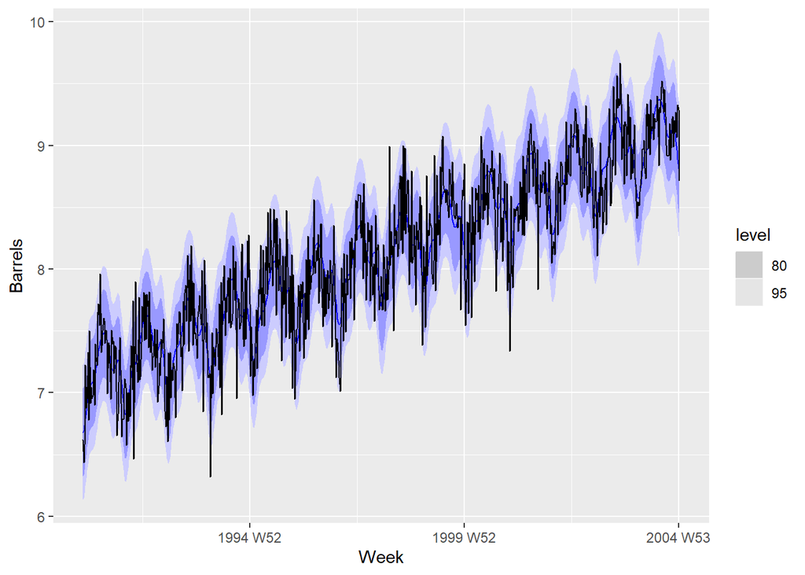

```r
gasolina%>%
  forecast(new_data = dados_2004)%>%
  autoplot(dados_2004)
```

```r
#b)Selecione o número apropriado de termos de Fourier para incluir minimizando o valor AICc ou CV.
gasolina<- dados_2004 %>%
  model(TSLM(Barrels ~ Week + fourier(K = 7)))
glance(gasolina) %>%
  select(adj_r_squared, CV, AIC, AICc, BIC)
```

```
## # A tibble: 1 x 5
##   adj_r_squared     CV    AIC   AICc    BIC
##           <dbl>  <dbl>  <dbl>  <dbl>  <dbl>
## 1         0.845 0.0739 -1892. -1891. -1814.
```

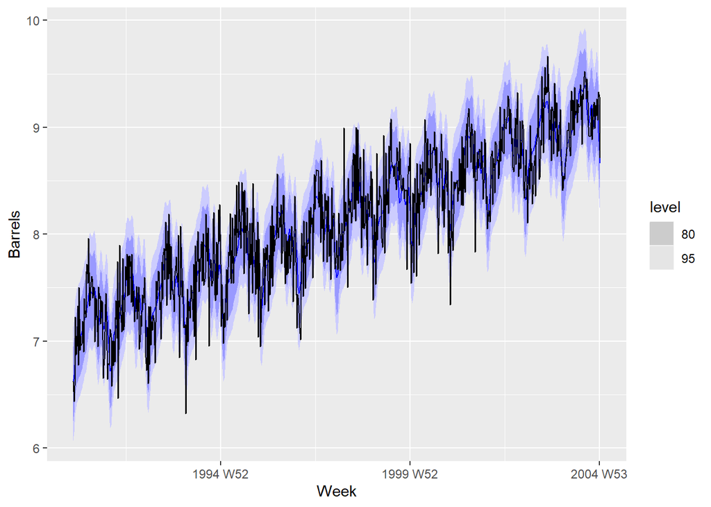

```r
gasolina%>%
  forecast(new_data = dados_2004)%>%
  autoplot(dados_2004)
```

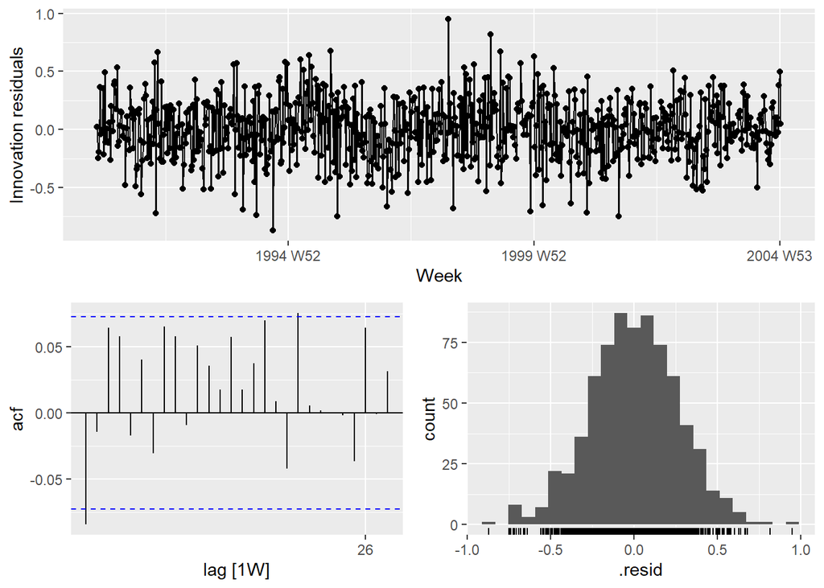

```r
#c)Trace os resíduos do modelo final usando a gg_tsresiduals()função e comente sobre eles. Use um teste Ljung-Box para verificar a autocorrelação residual.
gasolina%>%
  gg_tsresiduals()
```